# Análise de Churn - Petlove

Neste case, trabalharemos nos dados da Petlove&CO, a maior plataforma dedicada aos cuidados com animais de estimação na América Latina. A empresa oferece uma ampla variedade de serviços, abrangendo desde a gestão de suprimentos até cuidados de saúde, administração de negócios e serviços diários para os animais de estimação.

O enfoque central será na equipe responsável pelo serviço de Assinatura da Petlove&CO. Esse serviço permite que os tutores dos animais programem a entrega de produtos essenciais em períodos personalizados, além de receberem descontos e brindes exclusivos como assinantes.

O desafio enfrentado pela equipe é o churn, ou seja, a taxa de cancelamento de assinaturas. Apesar de contínuas melhorias na plataforma, observou-se um aumento no churn nos últimos meses.

Neste contexto, nossa missão é utilizar análises de dados para uma compreensão mais profunda do comportamento dos clientes. Buscaremos identificar possíveis razões por trás do aumento do churn e, principalmente, desenvolver estratégias eficazes para reduzir a perda de assinantes. Para isso, exploraremos diversos aspectos, tais como a relação entre o churn e o mês de cancelamento, a versão da assinatura, o canal de vendas, a faixa etária dos clientes e outros fatores relevantes.

Nossa análise visa fornecer insights valiosos para a equipe de Assinatura da Petlove&CO, a fim de apoiar suas decisões estratégicas e aprimorar a retenção de clientes. Ao basear nossas recomendações em fatos e dados concretos, buscamos contribuir para o alcance de resultados mais sólidos e consolidar a posição da empresa no mercado de animais de estimação.

## Análises

### Como nosso churn se comporta de acordo com o mês e ano?

A análise de churn ao longo dos meses é fundamental para entendermos as tendências de cancelamento de assinaturas ao longo do tempo. Observamos que os meses com maior número de churns foram dezembro de 2020, janeiro de 2021 e fevereiro de 2021. Já os meses com menor número de churns foram março de 2017, junho de 2017 e fevereiro de 2018. Essas informações sugerem a existência de padrões sazonais e podem nos indicar os períodos críticos em que os esforços para retenção de clientes devem ser intensificados.

Já ao longo dos anos, observamos que o churn segue crescendo (com a observação que não temos os dados completos de de 2021 ainda, para termos uma conclusão).

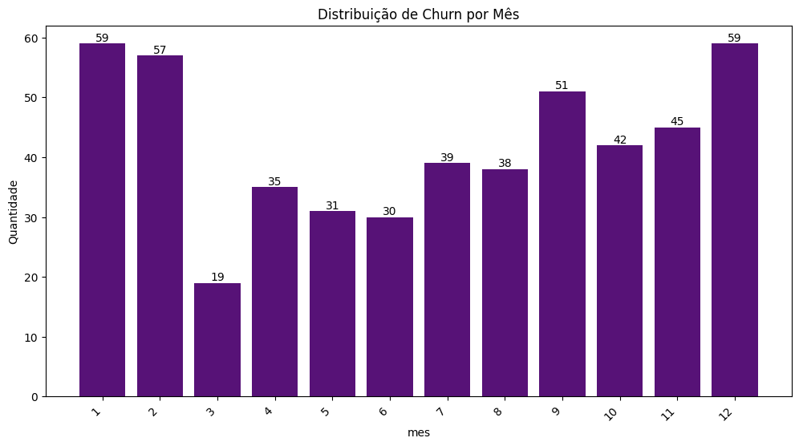

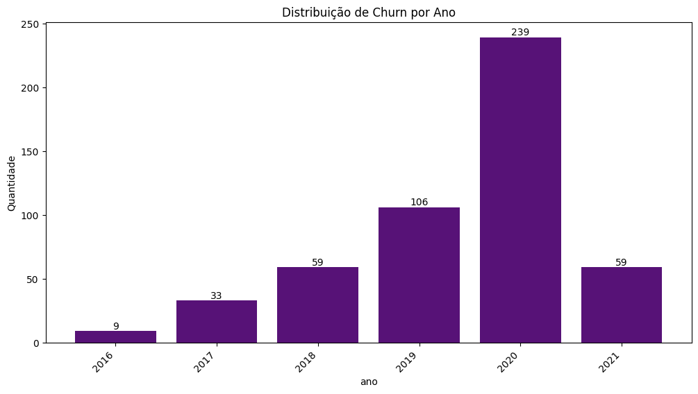

### Como nosso churn se comporta de acordo com a versão da assinatura?

Ao analisarmos o churn em relação à versão da assinatura, identificamos que as versões 3 e 4 apresentam um maior número absoluto de cancelamentos, sugerindo que essas versões enfrentam desafios em relação à retenção de clientes. No entanto, ao considerarmos a porcentagem de churn em relação ao total de assinantes de cada versão, notamos que elas não se destacam significativamente, indicando que o churn está relativamente distribuído entre as diferentes versões.

É importante ressaltar que as versões 6 e 7, apesar de terem um número menor de usuários, apresentam uma porcentagem mais alta de churn em relação ao total. Isso pode indicar a existência de problemas específicos nessas versões, ou funcionalidades menos atrativas para os clientes, o que pode estar impactando negativamente a retenção. Sendo assim, é recomendado uma análise mais aprofundada nessas versões para identificar as causas subjacentes ao churn e implementar estratégias de retenção direcionadas.

Essa análise é importante para determinar as versões que podem estar enfrentando problemas ou apresentando funcionalidades/serviços menos atrativas para os clientes, o que pode estar impactando negativamente a retenção.

|  | major_version | active | canceled | paused | Total | Churn (%) |
| --- | --- | --- | --- | --- | --- | --- |
| 0 | 0 | 9 | 1 | 1 | 11 | 9.09% |
| 1 | 1 | 173 | 13 | 17 | 203 | 6.4% |
| 2 | 2 | 1118 | 84 | 122 | 1324 | 6.34% |
| 3 | 3 | 2968 | 167 | 336 | 3471 | 4.81% |
| 4 | 4 | 2879 | 163 | 333 | 3375 | 4.83% |
| 5 | 5 | 1185 | 62 | 139 | 1386 | 4.47% |
| 6 | 6 | 182 | 14 | 21 | 217 | 6.45% |
| 7 | 7 | 10 | 1 | 2 | 13 | 7.69% |

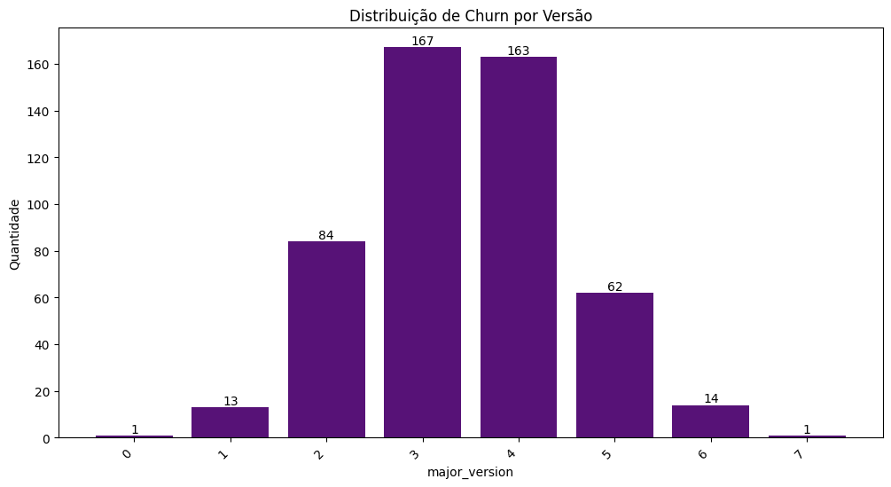

### Como nosso churn se comporta de acordo com o canal de vendas?

Essa análise destaca a importância de compreender o desempenho de cada canal de vendas em relação ao churn, permitindo a implementação de estratégias mais eficazes para retenção de clientes, especialmente naqueles canais com maiores índices de churn.

|  | marketing_source | active | canceled | paused | Total | Churn (%) |
| --- | --- | --- | --- | --- | --- | --- |
| 0 | crm | 874 | 43 | 112 | 1029 | 4.18% |
| 1 | direct | 1872 | 96 | 181 | 2149 | 4.47% |
| 2 | none | 439 | 34 | 56 | 529 | 6.43% |
| 3 | organic_search | 3118 | 196 | 385 | 3699 | 5.3% |
| 4 | paid_search | 1307 | 70 | 149 | 1526 | 4.59% |
| 5 | telegram_whatsapp | 914 | 66 | 88 | 1068 | 6.18% |

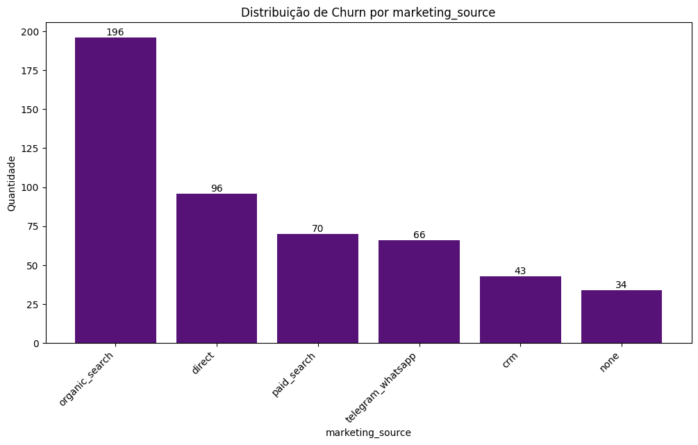

### Como nosso churn se comporta de acordo com a faixa etária do cliente?

Ao analisarmos o churn em relação à faixa etária dos clientes, identificamos que a faixa etária "31-45" possui maior quantidade de churn em relação ao total de assinantes. Contudo, ele também possui a menor % de churn em relação ao total de assinantes da faixa, indicando que clientes nessas faixas etárias têm maior probabilidade de manterem suas assinaturas ativas.

Enquanto isso, a faixa <31 possui a maior porcentagem de churn. Essa faixa etária representa um grupo de clientes que parece ser mais propenso a cancelar suas assinaturas.

Essa análise pode fornecer insights importantes sobre quais grupos etários estão mais propensos ao churn, permitindo a criação de estratégias segmentadas de retenção, direcionadas a cada faixa etária específica.

|  | faixa_etaria | active | canceled | paused | Total | Churn (%) |
| --- | --- | --- | --- | --- | --- | --- |
| 0 | <31 | 514 | 39 | 55 | 608 | 6.41% |
| 1 | 31-45 | 2346 | 118 | 241 | 2705 | 4.36% |
| 2 | 46-55 | 1525 | 98 | 179 | 1802 | 5.44% |
| 3 | 56-65 | 1541 | 93 | 184 | 1818 | 5.12% |
| 4 | 66-75 | 1442 | 91 | 192 | 1725 | 5.28% |
| 5 | 75+ | 1156 | 66 | 120 | 1342 | 4.92% |

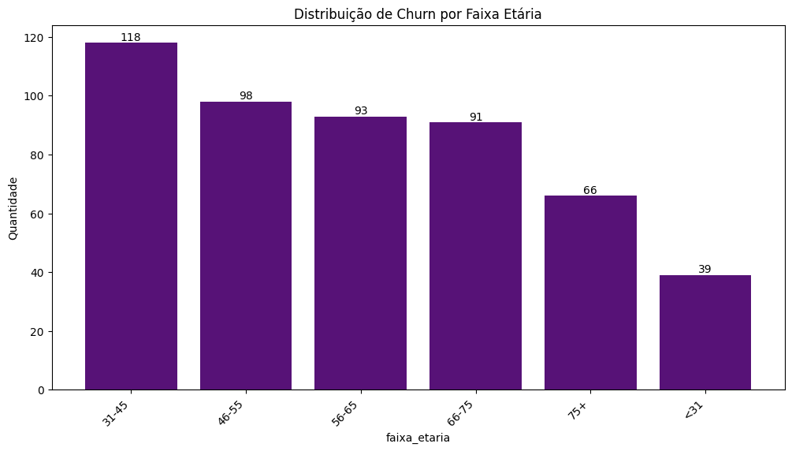

### Como nosso churn se comporta de acordo com o estado do cliente?

Analisando o churn em relação ao estado do cliente, observamos que o estado "RS" apresenta a maior quantidade total de churns, além de que, junto com SE, possui a maior porcentagem de churn em relação ao total de assinantes. Clientes localizados nesse estado têm maior probabilidade de cancelar suas assinaturas.

Por outro lado, os estados "PI" e "SC" exibem as menores porcentagens de churn, indicando que clientes nessas localidades têm maior probabilidade de permanecerem ativos.

Essa análise ressalta a importância de avaliar o comportamento de churn em diferentes estados, a fim de identificar possíveis padrões regionais e implementar estratégias específicas para melhorar a retenção de clientes em cada região.

|  | state | active | canceled | paused | Total | Churn (%) |
| --- | --- | --- | --- | --- | --- | --- |
| 0 | AC | 297 | 16 | 44 | 357 | 4.48% |
| 1 | AL | 301 | 22 | 30 | 353 | 6.23% |
| 2 | AM | 326 | 23 | 31 | 380 | 6.05% |
| 3 | AP | 334 | 15 | 32 | 381 | 3.94% |
| 4 | BA | 314 | 20 | 34 | 368 | 5.43% |
| 5 | CE | 325 | 19 | 34 | 378 | 5.03% |
| 6 | DF | 306 | 15 | 36 | 357 | 4.2% |
| 7 | ES | 303 | 12 | 37 | 352 | 3.41% |
| 8 | GO | 344 | 21 | 38 | 403 | 5.21% |
| 9 | MA | 303 | 23 | 28 | 354 | 6.5% |
| 10 | MG | 320 | 19 | 34 | 373 | 5.09% |
| 11 | MS | 305 | 20 | 49 | 374 | 5.35% |
| 12 | MT | 308 | 24 | 36 | 368 | 6.52% |
| 13 | PA | 284 | 22 | 45 | 351 | 6.27% |
| 14 | PB | 331 | 14 | 27 | 372 | 3.76% |
| 15 | PE | 309 | 20 | 38 | 367 | 5.45% |
| 16 | PI | 290 | 11 | 37 | 338 | 3.25% |
| 17 | PR | 330 | 17 | 38 | 385 | 4.42% |
| 18 | RJ | 323 | 16 | 38 | 377 | 4.24% |
| 19 | RN | 306 | 15 | 32 | 353 | 4.25% |
| 20 | RO | 329 | 17 | 35 | 381 | 4.46% |
| 21 | RR | 327 | 23 | 46 | 396 | 5.81% |
| 22 | RS | 317 | 25 | 40 | 382 | 6.54% |
| 23 | SC | 323 | 12 | 35 | 370 | 3.24% |
| 24 | SE | 305 | 24 | 38 | 367 | 6.54% |
| 25 | SP | 308 | 16 | 30 | 354 | 4.52% |
| 26 | TO | 356 | 24 | 29 | 409 | 5.87% |

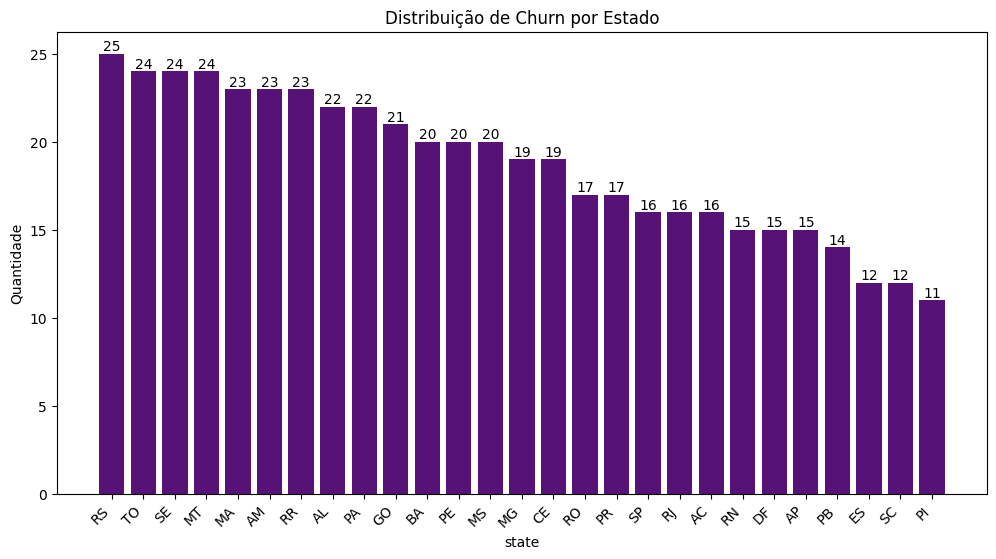